# Active Learning for Text Classification

# Classifying Wiki Detox Comments

Here we use a simple active learning approach for building a text classifier.

```r
### Libraries ###
library(dplyr)
library(ggplot2)
library(tidyr)
library(pROC)
library(randomForest)

source("active_learning_lib_reticulate.R")

FEATURIZED_DATA_FILE <- "featurized_wiki_comments_attack.Rds"
RANDOM_TS_PERFORMANCE_FILE <- "passive_learning_curves_data.Rds"
TEST_SET_SIZE <- 10000

if (!file.exists(FEATURIZED_DATA_FILE)){
  storage_address <- 'https://activelearnwestus.blob.core.windows.net/activelearningdemo/'
  download_url <- paste0(storage_address, FEATURIZED_DATA_FILE)
  download.file(download_url, FEATURIZED_DATA_FILE)
}
```

```r
# params <- list(seed=1, initial_examples_per_class=20, examples_to_label_per_iteration=20, num_iterations=20, presample_size=20000, monte_carlo_samples=10, mu=0.5, sigma=0.1)
params
```

```
## $seed
## [1] 3
##
## $initial_examples_per_class
## [1] 20
##
## $examples_to_label_per_iteration
## [1] 10
##
## $num_iterations
## [1] 20
##
## $presample_size
## [1] 20000
##
## $monte_carlo_samples
## [1] 100
##
## $mu
## [1] 0.5
##
## $sigma
## [1] 0.1
```

```r
set.seed(1)

FEATURIZED_DATA <- readRDS(FEATURIZED_DATA_FILE)
FEATURIZED_DATA <- FEATURIZED_DATA[complete.cases(FEATURIZED_DATA),]

test_set_ids <- sample(FEATURIZED_DATA$rev_id, TEST_SET_SIZE)
TEST_SET <- FEATURIZED_DATA %>% filter(rev_id %in% test_set_ids)

unlabeled_data_df <- FEATURIZED_DATA[!(FEATURIZED_DATA$rev_id %in% TEST_SET$rev_id),]

inputs <- grep("^V", names(FEATURIZED_DATA), value=TRUE)
outcome <- "flagged"
FORM <- paste0(outcome, ' ~ ', paste(inputs, collapse="+"), " - 1")
```

### Split labeled data into training and test sets

```r
set.seed(params$seed)

initial_training_set <- FEATURIZED_DATA %>%
  group_by(flagged) %>%
  do(sample_n(., params$initial_examples_per_class)) %>%
  ungroup %>%
  as.data.frame

table(initial_training_set$flagged)
```

```
##
## FALSE  TRUE
##    20    20
```

```r
table(TEST_SET$flagged)
```

```
##
## FALSE  TRUE
##  8613  1387
```

```r
table(TEST_SET$flagged)/nrow(TEST_SET)
```

```
##
##  FALSE   TRUE
## 0.8613 0.1387
```

## Case selection function

```r
get_uncertainty_function <- function(pred_df){
  # Use a function with a max around mu, to score predicted prob.
  function(x){
    dnorm(x, mean=params$mu, sd=params$sigma)
  }
}

gen_candidate_cases <- function(available_cases, presample_size=params$presample_size) {
    # Select a presample of cases to evaluate.
    presample_size <- min(nrow(available_cases), presample_size)
    candidate_cases <- available_cases[sample(1:nrow(available_cases), presample_size),]
    candidate_cases
}

# Current result  - the model to use to eval candidates.
# Available_cases - unlabelled data to chose from
select_cases <- function(current_results, available_cases, N=params$examples_to_label_per_iteration){

    candidate_cases <- gen_candidate_cases(available_cases)
    model <- current_results$model
    X_candidates <- model.matrix(formula(FORM), candidate_cases)
    votes_vec <- model$predict_proba(X_candidates)[,2]
    predictions_df <- data.frame(rev_id=candidate_cases$rev_id,
                                  flagged=candidate_cases$flagged,
                                  predicted=votes_vec > 0.5,
                                  estimated_probability=votes_vec)

    uncertainty <- get_uncertainty_function(current_results$test_predictions)

    p <- predictions_df$estimated_probability
    u <- uncertainty(p)
    # sample from the available predictions, weighted by probability u.
    s <- sample(predictions_df$rev_id, N, prob=u, replace=FALSE)
    selected <- predictions_df %>% filter(rev_id %in% s)

    return(selected)
}

select_outlier_cases <- function(current_results, available_cases, presample_size=params$presample_size, N=params$examples_to_label_per_iteration){
      candidate_cases <- gen_candidate_cases(available_cases, presample_size)
      pairwise_distances <- distance_mat(candidate_cases, presample_size) #passed globally :()
      candidate_cases <- feature_density_est(candidate_cases, presample_size)
      candidate_cases[order(candidate_cases$density)[1:N],]
}
```

Different methods to chose samples

```r
source("density_estimates.R")
select_outlier_cases(NULL, unlabeled_data_df, 60, 10)$density
```

## Initial model

First we build a model on the small number of examples in the initial training set, and test on the test data.

### Fit model to initial training set

```r
initial_model_results <- fit_and_evaluate_model(initial_training_set)
initial_model_results$selected <-  select_cases(initial_model_results, unlabeled_data_df)
```

### Results for initial model

#### Confusion matrix

```r
initial_model_results$confusion
```

```
##        predicted
## flagged FALSE TRUE
##   FALSE  6032 2581
##   TRUE    320 1067
```

#### Performance summary

```r
initial_model_results$performance
```

```
##        tss   accuracy        auc
## 40.0000000  0.7099000  0.8204369
```

## Iterate modelling, case selection, and (pseudo) labelling

```r
new_sample <- initial_model_results$selected %>% get_new_pseudolabeled_sample(unlabeled_data_df)

current_training_set <- rbind(initial_training_set, new_sample[names(initial_training_set)])

ALREADY_EVALUATED <- initial_model_results$selected$rev_id

iteration_results <- lapply(1:params$num_iterations, function(i){
  results <- fit_and_evaluate_model(current_training_set)

  candidate_cases <- unlabeled_data_df[(unlabeled_data_df$rev_id %in% setdiff(unlabeled_data_df$rev_id,
                                                                                ALREADY_EVALUATED)),]
  results$selected <- select_cases(results, candidate_cases)

  ALREADY_EVALUATED <<- c(ALREADY_EVALUATED, results$selected$rev_id)

  next_sample <- results$selected %>% get_new_pseudolabeled_sample(unlabeled_data_df)

  current_training_set <<- rbind(current_training_set, next_sample[names(current_training_set)])

  results
})
```

```r
# current_training_set also includes the ones selected on the last round
not_run_yet <- iteration_results[[length(iteration_results)]]$selected$rev_id
training_set <- current_training_set[!(current_training_set$rev_id %in% not_run_yet),]

write.csv(training_set, sprintf("training_set_%02d.csv", params$seed), row.names=FALSE, quote=FALSE)
write.csv(TEST_SET, sprintf("test_set_%02d.csv", params$seed), row.names=FALSE, quote=FALSE)
```

This shows the change in the metrics, with each row showing an iteration.

```r
iteration_performance <- do.call("rbind", lapply(iteration_results, function(ires) ires$performance))

(performance_table <- rbind(initial_model_results$performance, iteration_performance))
```

```
##       tss accuracy       auc
##  [1,]  40   0.7099 0.8204369
##  [2,]  50   0.7974 0.8440060
##  [3,]  60   0.8316 0.8344950
##  [4,]  70   0.8475 0.8337777
##  [5,]  80   0.8639 0.8404460
##  [6,]  90   0.8602 0.8414330
##  [7,] 100   0.8738 0.8388367
##  [8,] 110   0.8724 0.8437924
##  [9,] 120   0.8758 0.8490805
## [10,] 130   0.8858 0.8424110
## [11,] 140   0.8852 0.8312547
## [12,] 150   0.8831 0.8345046
## [13,] 160   0.8855 0.8363951
## [14,] 170   0.8833 0.8417524
## [15,] 180   0.8933 0.8551131
## [16,] 190   0.8939 0.8561745
## [17,] 200   0.8908 0.8462704
## [18,] 210   0.8931 0.8469252
## [19,] 220   0.8927 0.8434988
## [20,] 230   0.8926 0.8446850
## [21,] 240   0.8916 0.8415269
```

## Final model results

### Confusion Matrix

```r
final_model_results <- iteration_results[[params$num_iterations]]
final_model_results$confusion
```

```
##        predicted
## flagged FALSE TRUE
##   FALSE  8468  145
##   TRUE    939  448
```

### Performance summary

Summary of performance using cases selected with active learning:

```r
(selected_sample_results <- final_model_results$performance)
```

```
##         tss    accuracy         auc
## 240.0000000   0.8916000   0.8415269
```

### Visualizing improvement for actively learned model

This series of ROC curves shows how performance changes with iterations of active learning.

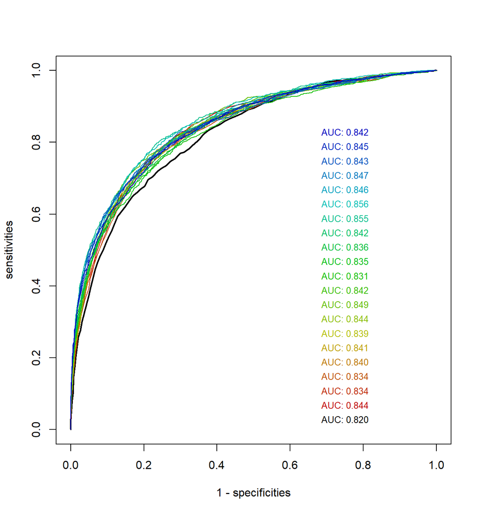

```r
plot_roc_history(initial_model_results, iteration_results)
```

### Comparing learning curves of active and passive learning

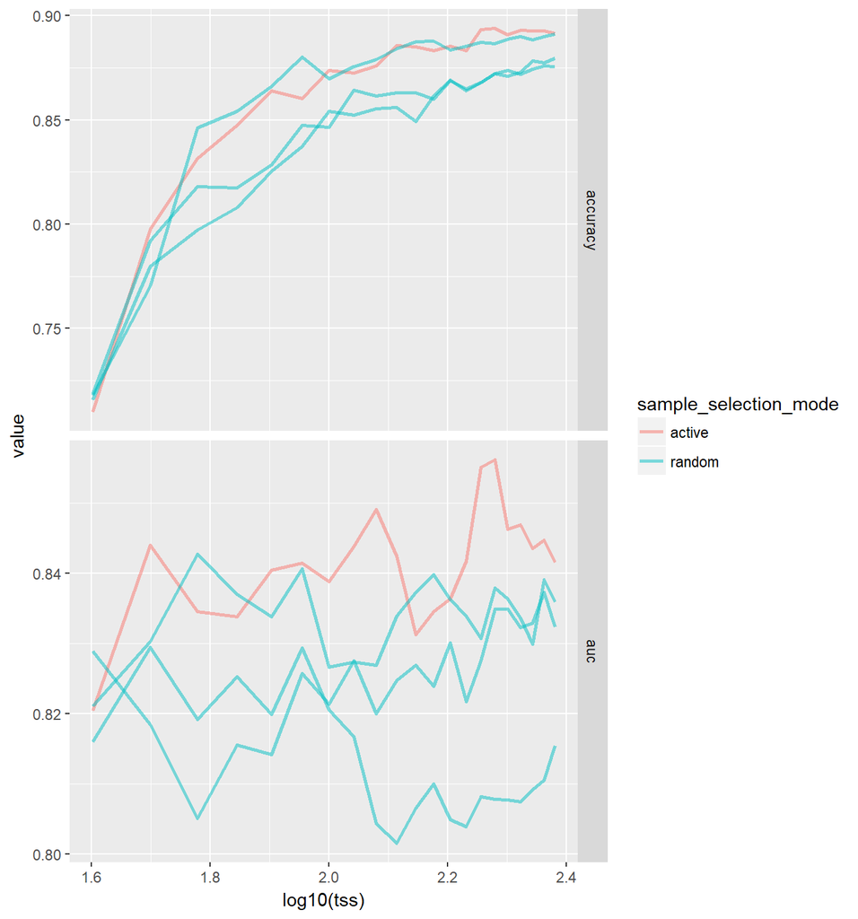

```r
get_random_training_set_performance <- function(ts_sizes){
  random_training_set <- initial_training_set

  random_training_set_results <- lapply(c(0,diff(ts_sizes)), function(tss){
    new_ids <- sample(setdiff(unlabeled_data_df$rev_id, random_training_set$rev_id), tss)
    new_cases <- unlabeled_data_df %>% filter(rev_id %in% new_ids)
    random_training_set <<- rbind(random_training_set, new_cases)
    fit_and_evaluate_model(random_training_set)
  })

  random_ts_performance <- random_training_set_results %>%
    lapply("[[", "performance") %>%
    do.call(bind_rows, .)

  random_ts_performance$sample_selection_mode <- "random"

  random_ts_performance
}

performance_table <- as.data.frame(performance_table)
ts_sizes <- performance_table$tss

if (file.exists(RANDOM_TS_PERFORMANCE_FILE)){
  random_ts_performance_list <- readRDS(RANDOM_TS_PERFORMANCE_FILE)
} else {
  NUM_TSS_COMPARISONS <- 3
  random_ts_performance_list <- lapply(1:NUM_TSS_COMPARISONS, function(i){
    rtsp <- get_random_training_set_performance(ts_sizes)
    rtsp$group <- i
    rtsp
  })

  saveRDS(random_ts_performance_list, RANDOM_TS_PERFORMANCE_FILE)
}

performance_table$sample_selection_mode <- "active"
performance_table$group <- 0

performance_data <- bind_rows(random_ts_performance_list, performance_table)
names(performance_data)[5] <- "run"

performance_data %>%
  gather(key="metric", value="value", -tss, -sample_selection_mode, -run) %>%
  ggplot(aes(x=log10(tss), y=value, col=sample_selection_mode, group=run)) +
    geom_line(size=1, alpha=0.5) +
    facet_grid(metric ~ ., scales="free")
```

## Monte Carlo Estimation of P-values

What is the probability that a set of randomly chosen cases would improve the performance of the model as much as the selected cases did? We’ll add the same number of examples to the training set, except that now they will be randomly chosen. We’ll repeat this sampling, training, and evaluation process 100 times, and see how many of those times we beat the performance of the selected cases.

```r
(N <- iteration_results[[params$num_iterations]]$performance[['tss']] - nrow(initial_training_set))
```

```
## [1] 200
```

```r
available_cases <- unlabeled_data_df

random_sample_results <- sapply(1:params$monte_carlo_samples, function(i){
  new_sample <- available_cases[sample(1:nrow(available_cases), N, replace=FALSE),]

  training_set_new <- rbind(initial_training_set, new_sample[names(initial_training_set)])

  fit_and_evaluate_model(training_set_new)$performance
})
```

### P-values

```r
mapply (
  function(metric) sum(random_sample_results[metric,] >= selected_sample_results[[metric]]),
  row.names(random_sample_results)
) / params$monte_carlo_samples
```

```
##      tss accuracy      auc
##     1.00     0.01     0.04
```

## Model trained with all available “unlabeled” cases

For comparison, we’ll build a model as though we had gone through and labeled all 105374 of the usable new examples.

```r
FULL_MODEL_RESULTS_FILE <- "full_model_results.Rds"
```

```r
training_set_full <- rbind(initial_training_set, available_cases[names(initial_training_set)])

if (file.exists(FULL_MODEL_RESULTS_FILE)){
  full_model_results <- readRDS(FULL_MODEL_RESULTS_FILE)
} else {
  full_model_results <- fit_and_evaluate_model(training_set_full)
  saveRDS(full_model_results, FULL_MODEL_RESULTS_FILE)
}

full_model_results$confusion
```

```
##        predicted
## flagged FALSE TRUE
##   FALSE  8517   96
##   TRUE    857  530
```

```r
full_model_results$performance
```

```
##          tss     accuracy          auc
## 1.054140e+05 9.047000e-01 8.876104e-01
```

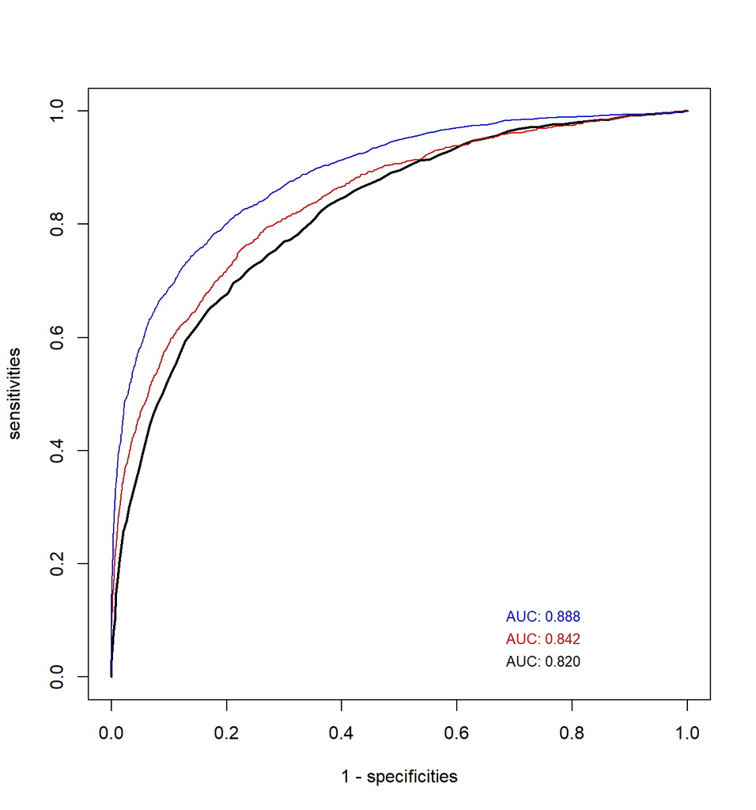

```r
plot_roc_history(initial_model_results, list(final_model_results, full_model_results))
```

## Compare initial model to final model predictions [[NEW]]

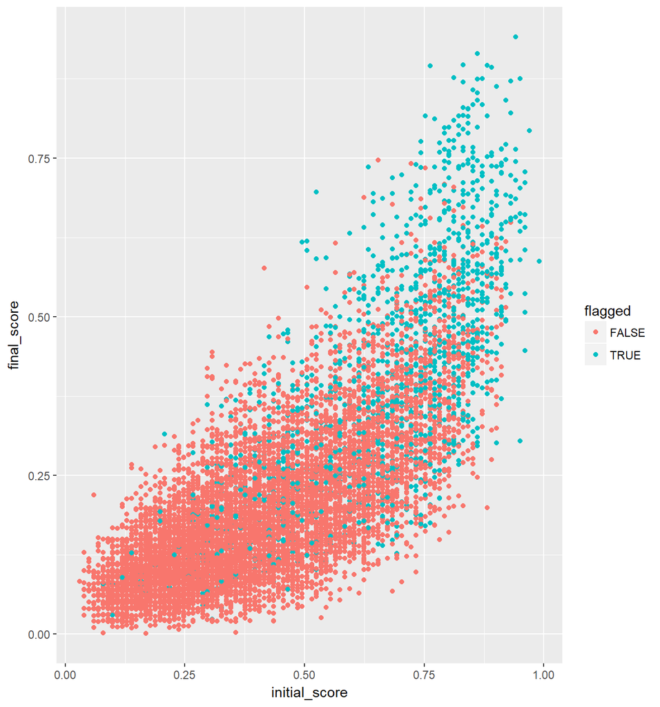

```r
final_res <- final_model_results$test_predictions[c("rev_id", "estimated_probability")]
names(final_res)[2] <- 'final_score'

full_res <- full_model_results$test_predictions[c("rev_id", "estimated_probability")]
names(full_res)[2] <- 'full_score'


pred_frame <- initial_model_results$test_predictions %>%
  mutate(initial_score = estimated_probability) %>%
  select(rev_id, flagged, initial_score) %>%
  inner_join(final_res, by="rev_id") %>%
  inner_join(full_res, by="rev_id")

pred_frame %>% ggplot(aes(x=initial_score, y=final_score, col=flagged)) + geom_point()
```

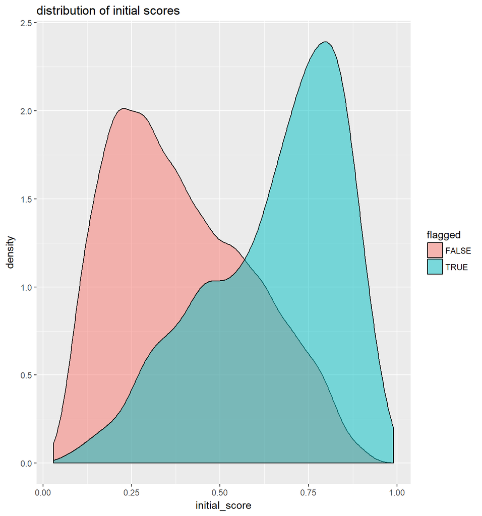

```r
pred_frame %>% ggplot(aes(x=initial_score, fill=flagged)) +
  geom_density(alpha=0.5) + ggtitle("distribution of initial scores")
```

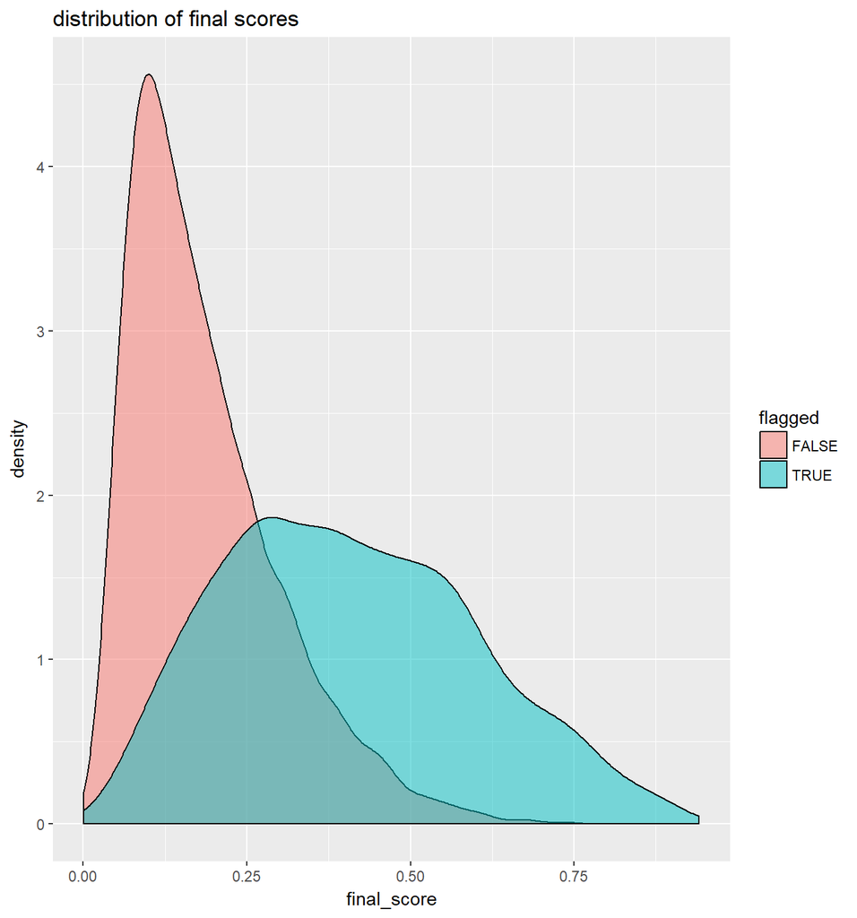

```r
pred_frame %>% ggplot(aes(x=final_score, fill=flagged)) +
  geom_density(alpha=0.5) + ggtitle("distribution of final scores")
```

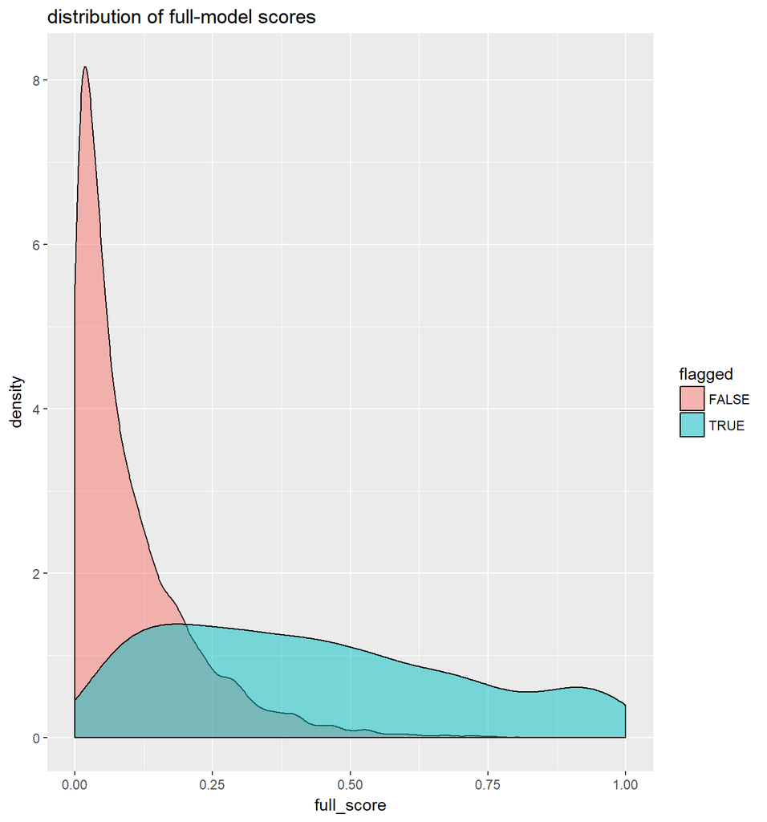

```r
pred_frame %>% ggplot(aes(x=full_score, fill=flagged)) +
  geom_density(alpha=0.5) + ggtitle("distribution of full-model scores")
```

Let’s look at some examples of comments that are false negatives under the final model.

```r
text_data <- read.csv("text_data.csv", stringsAsFactors=FALSE) # actually, we only need the text from the test set...

text_data$text <- text_data$text %>%
  gsub("NEWLINE_TOKEN", "\n", .) %>%
  gsub("\n+", "\n", .) %>%
  gsub(" +", " ", .)

false_negatives <- with(final_model_results$test_predictions,
                        rev_id[(estimated_probability < 0.1) & flagged])

false_neg_data <- text_data[text_data$rev_id %in% false_negatives, ]

false_neg_data$text[1:5]
```

[output not shown]

# TO DO:

- Featurize with an embedding that contains more dirty words (e.g., Reddit NSFW).
- `estimated_probability` is really just a score in the range between 0 and 1.
- Use a smarter uncertainty function; target utility.